# Geog533 Lab 6 - ANOVA

Alyssa James

Complete the following exercises in Chapter 6 (Analysis of Variance) of the textbook pages 199-203. For each question, you need to specify the null hypothesis and why you accept or reject the null hypothesis.

## Question 1

This is Exercise 2 in Chapter 6 of the Textbook [R].

### Problem

Assume that an analysis of variance is conducted for a study where there are $N = 50$ observations and $k = 5$ categories. Fill in the blanks in the following ANOVA table:

|  | Sum of squares | Degrees of freedom | Mean square | *F* |
| --- | --- | --- | --- | --- |
| Between |  |  | 116.3 |  |
| Within | 2000 |  |  |  |
| Total |  |  |  |  |

### Solution

```r
N <- 50
k <- 5
BSS <- 116.3*df1
TSS <- BSS+2000
ms <- 2000*(N-k)
F <- 116.3/ms
## define the variables here, and use the imbedded r code like `r variable` to fill in the blanks.
```

[output not shown]

## Question 2

This is Exercise 6 in Chapter 6 of the Textbook [R].

### Problem

Is there a significant difference between the distances moved by low- and high-income individuals? Twelve respondents in each of the income categories are interviewed, with the following results for the distances associated with residential moves:

| Respondent | Low income | High income |
| --- | --- | --- |
| 1 | 5 | 25 |
| 2 | 7 | 24 |
| 3 | 9 | 8 |
| 4 | 11 | 2 |
| 5 | 13 | 11 |
| 6 | 8 | 10 |
| 7 | 10 | 10 |
| 8 | 34 | 66 |
| 9 | 17 | 113 |
| 10 | 50 | 1 |
| 11 | 17 | 3 |
| 12 | 25 | 5 |
| Mean | 17.17 | 23.17 |
| Std. dev. | 13.25 | 33.45 |

### Solution

```r
N <- 12
mean <- 20.17
s <- 23.35
Low <- c(5, 7, 9, 11, 13, 8, 10, 34, 17, 50, 17, 25)
High <- c(25, 24, 8, 2, 11, 10, 10, 66, 113, 1, 3 ,5)
Income <- c(Low, High)
groups <- c(rep("Low", 12), rep("High", 12))
df <- data.frame(Income, groups)
m <- aov(Income~groups, data = df)
summary(m)
```

```
            Df Sum Sq Mean Sq F value Pr(>F)
groups       1    216   216.0   0.334  0.569
Residuals   22  14241   647.3
```

```r
qf(0.90, df1 = 1, df2 = 22)
```

```
[1] 2.948585
```

```r
print("We cannot reject the null hypothesis")
```

```
[1] "We cannot reject the null hypothesis"
```

## Question 3

This is Exercise 9 in Chapter 6 of the Textbook [R].

### Problem

A sample is taken of incomes in three neighborhoods, yielding the following data:

|  | A | B | C | Overall (Combined sample) |
| --- | --- | --- | --- | --- |
| N | 12 | 10 | 8 | 30 |
| Mean | 43.2 | 34.3 | 27.2 | 35.97 |
| Std. dev. | 36.2 | 20.3 | 21.4 | 29.2 |

### Solution

```r
N <- 30
Mean <- 35.97
s <- 29.2
TSS <- (N-1)*s^2
WSS <- (12-1)*36.2^2 + (10-1)*20.3^2 + (8-1)*21.4^2
BSS <- TSS - WSS
df1 <- 2
df2 <- 27
df3 <- 29
ms1 <- BSS/df1
ms2 <- WSS/df2
F <- ms1/ms2
F
```

```
[1] 2.150184
```

```r
qf(0.95, df1 = 2, df2 = 27)
```

```
[1] 3.354131
```

```r
print("We cannot reject the null hypothesis")
```

```
[1] "We cannot reject the null hypothesis"
```

## Question 4

This is Exercise 10 in Chapter 6 of the Textbook [R].

### Problem

| Col 1 | Col 2 | Col 3 | Col 4 |
| --- | --- | --- | --- |
| 23.1 | 43.1 | 56.5 | 10002.3 |
| 13.3 | 10.2 | 32.1 | 54.4 |
| 15.6 | 16.2 | 43.3 | 8.7 |
| 1.2 | 0.2 | 24.4 | 54.4 |

### Solution

```r
Col.1 <- c(23.1, 13.3, 15.6, 1.2)
Col.2 <- c(43.1, 10.2, 16.2, 0.2)
Col.3 <- c(56.5, 32.1, 43.3, 24.4)
Col.4 <- c(10002.3, 54.4, 8.7, 54.4)
Columns <- c(Col.1, Col.2, Col.3, Col.4)
groups <- c(rep("Col.1", 4), rep("Col.2", 4), rep("Col.3", 4), rep("Col.4", 4))
library(graphics)
df <- data.frame(Columns, groups)
kt <- kruskal.test(Columns~groups, data = df)
kt
```

```
    Kruskal-Wallis rank sum test

data:  Columns by groups
Kruskal-Wallis chi-squared = 6.3844, df = 3, p-value = 0.09434
```

```r
print("We cannot reject the null hypothesis")
```

```
[1] "We cannot reject the null hypothesis"
```

## Question 5

This is Exercise 12 in Chapter 6 of the Textbook [R].

### Problem

A researcher wishes to know whether distance traveled to work varies by income. Eleven individuals in each of three income groups are surveyed. The resulting data are as follows (in commuting miles, one-way):

```r
## This is the script to generate the table. Do not write your answer inside in this block.
Observations <- seq(1:11)
Low <- c(5,4,1,2,3,10,6,6,4,12,11)
Medium <- c(10,10,8,6,5,3,16,20,7,3,2)
High <- c(8,11,15,19,21,7,7,4,3,17,18)
df <- data.frame(Observations,Low,Medium,High)
library(knitr)
kable(df)
```

| Observations | Low | Medium | High |
| --- | --- | --- | --- |
| 1 | 5 | 10 | 8 |
| 2 | 4 | 10 | 11 |
| 3 | 1 | 8 | 15 |
| 4 | 2 | 6 | 19 |
| 5 | 3 | 5 | 21 |
| 6 | 10 | 3 | 7 |
| 7 | 6 | 16 | 7 |
| 8 | 6 | 20 | 4 |
| 9 | 4 | 7 | 3 |
| 10 | 12 | 3 | 17 |
| 11 | 11 | 2 | 18 |

### Solution

```r
survey <- c(Low, Medium, High)
groups <- c(rep("Low", 11), rep("Medium", 11), rep("High", 11))
Obs <- data.frame(Low, Medium, High)
m <- aov(survey~groups, data = Obs)
summary(m)
```

```
            Df Sum Sq Mean Sq F value Pr(>F)
groups       2  201.0  100.48   3.493 0.0433 *
Residuals   30  862.9   28.76
---
Signif. codes:  0 *** 0.001 ** 0.01 * 0.05 . 0.1   1
```

```r
qf(0.95, df1 = 2, df2 = 30)
```

```
[1] 3.31583
```

```r
print("We reject the null hypothesis")
```

```
[1] "We reject the null hypothesis"
```

```r
library(reshape2)
install.packages("car")
library(car)
leveneTest(survey~groups, data = Obs)
```

```
group coerced to factor.
```

```
Levene's Test for Homogeneity of Variance (center = median)
      Df F value Pr(>F)
group  2  2.1694 0.1318
      30
```

```r
print("We cannot reject the null hypothesis")
```

```
[1] "We cannot reject the null hypothesis"
```

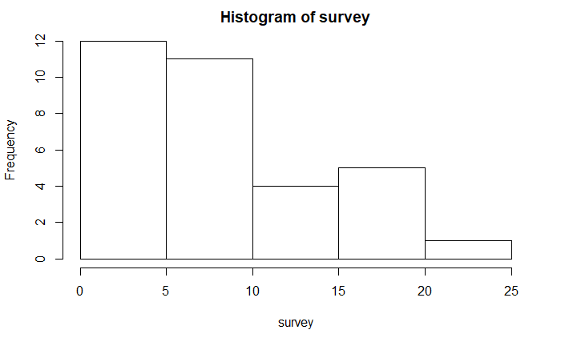

```r
hist(survey)
```

```r
shapiro.test(survey)
```

```
    Shapiro-Wilk normality test

data:  survey
W = 0.90693, p-value = 0.008099
```

```r
print("The data are not normally distributed")
```

```
[1] "The data are not normally distributed"
```

## Question 6

This is Exercise 13 in Chapter 6 of the Textbook [R].

### Problem

Data are collected on automobile ownership by surveying residents in central cities, suburbs and rural areas. The results are:

|  | Central cities | Suburbs | Rural areas |
| --- | --- | --- | --- |
| Number of observations | 10 | 15 | 15 |
| mean | 1.5 | 2.6 | 1.2 |
| Std. dev | 1.0 | 1.1 | 1.2 |
| Overall mean: 1.725 |  |  |  |
| Overall std.dev: 1.2 |  |  |  |

Test the null hypothesis that the means are equal in all three areas.

### Solution

```r
N <- 40
s <- 1.2
TSS <- (N-1)*s^2
WSS <- (10-1)*1^2 + (15-1)*1.1^2 + (15-1)*1.2^2
BSS <- TSS-WSS
df1 <- 2
df2 <- 37
df3 <- 39
ms1 <- BSS/df1
ms2 <- WSS/df2
F <- ms1/ms2
F
```

```
[1] 4.037093
```

```r
qf(0.95, df1 = 2, df2 = 37)
```

```
[1] 3.251924
```

```r
print("We reject the null hypothesis")
```

```
[1] "We reject the null hypothesis"
```